# Practical Machine Learning: Course Project

# Introduction

Using devices such as Jawbone Up, Nike FuelBand, and Fitbit it is now possible to collect a large amount of data about personal activity relatively inexpensively. These type of devices are part of the quantified self movement - a group of enthusiasts who take measurements about themselves regularly to improve their health, to find patterns in their behavior, or because they are tech geeks. One thing that people regularly do is quantify how much of a particular activity they do, but they rarely quantify how well they do it.

The goal of this project is to predict the manner in which 6 participants did the exercise. They were asked to perform barbell lifts correctly and incorrectly in 5 different ways.

# Data Processing

For this project, we will use the training data from (https://d396qusza40orc.cloudfront.net/predmachlearn/pml-training.csv) and the test data from (https://d396qusza40orc.cloudfront.net/predmachlearn/pml-testing.csv)

Firstly, load the related R packages for this analysis and load the training and testing datasets.

```r
library(caret)
library(rattle)
```

```r
library(rpart)
library(rpart.plot)
library(randomForest)
library(repmis)
```

```r
training <- read.csv("pml-training.csv", na.strings = c("NA", ""))
testing <- read.csv("pml-testing.csv", na.strings = c("NA", ""))
```

Some of the variables have missing value, therefore we delete the variables or predictors that contain any missing values.

```r
training <- training[, colSums(is.na(training)) == 0]
testing <- testing[, colSums(is.na(testing)) == 0]
```

We also delete the predictors that have a little predicting power to the classe variable.

```r
#remove the first 7 predictors:
# X, user_name, raw_timestamp_part_1, raw_timestamp_part_2, cvtd_timestamp, new-window, num_window
newTrain <- training[, -c(1:7)]
newTest <- testing[, -c(1:7)]
```

# Model Building

To get the out-of-sample error, we split the training dataset into the prediction dataset (train1) and validation dataset (train2) with 70% dan 30%.

```r
set.seed(4321)
myTrain <- createDataPartition(newTrain$classe, p = 0.7, list = FALSE)
train1 <- newTrain[myTrain, ]
train2 <- newTrain[-myTrain, ]
```

Then, We use classification trees and random forests to predict the outcome.

## Classification Trees

```r
#Classification trees
control <- trainControl(method = "cv", number = 5)
fit_rpart <- train(classe ~ ., data = train1, method = "rpart", trControl = control)
print(fit_rpart, digits = 4)
```

```
## CART
##
## 13737 samples
##    52 predictor
##     5 classes: 'A', 'B', 'C', 'D', 'E'
##
## No pre-processing
## Resampling: Cross-Validated (5 fold)
## Summary of sample sizes: 10990, 10989, 10990, 10991, 10988
## Resampling results across tuning parameters:
##
##   cp       Accuracy  Kappa    Accuracy SD  Kappa SD
##   0.03621  0.5091    0.35890  0.01952      0.02703
##   0.06001  0.4149    0.20667  0.06813      0.11413
##   0.11535  0.3318    0.07253  0.04335      0.06630
##
## Accuracy was used to select the optimal model using  the largest value.
## The final value used for the model was cp = 0.03621.
```

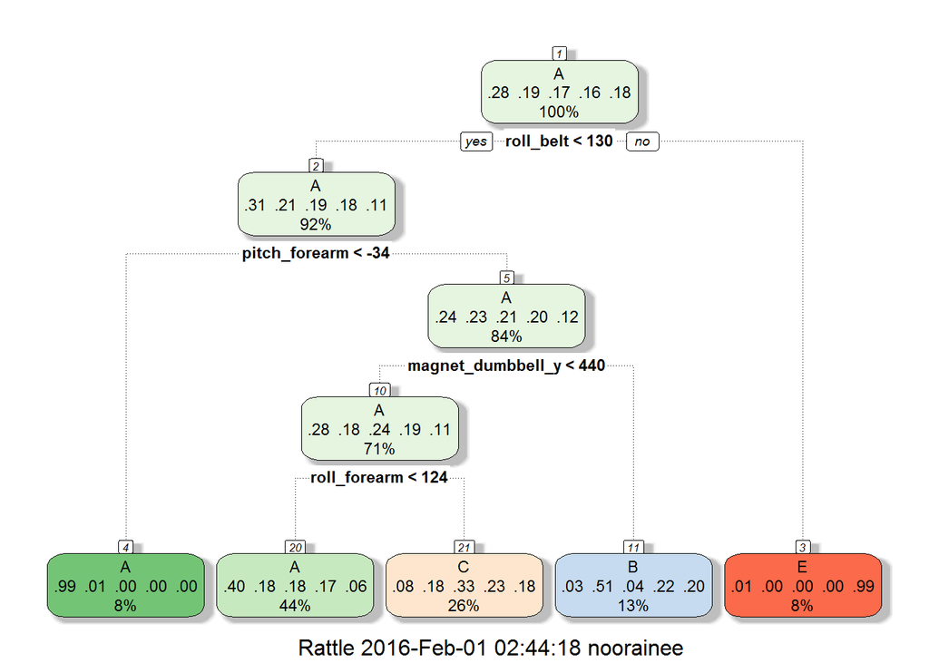

```r
fancyRpartPlot(fit_rpart$finalModel)
```

```r
# predict outcomes using validation set
predict_rpart <- predict(fit_rpart, train2)

(conf_rpart <- confusionMatrix(train2$classe, predict_rpart))
```

```
## Confusion Matrix and Statistics
##
##           Reference
## Prediction    A    B    C    D    E
##          A 1532   24  116    0    2
##          B  469  382  288    0    0
##          C  468   41  517    0    0
##          D  427  184  353    0    0
##          E  152  134  311    0  485
##
## Overall Statistics
##
##                Accuracy : 0.4955
##                  95% CI : (0.4826, 0.5084)
##     No Information Rate : 0.5179
##     P-Value [Acc > NIR] : 0.9997
##
##                   Kappa : 0.3408
##  Mcnemar's Test P-Value : NA
##
## Statistics by Class:
##
##                      Class: A Class: B Class: C Class: D Class: E
## Sensitivity            0.5026  0.49935  0.32618       NA  0.99589
## Specificity            0.9499  0.85215  0.88163   0.8362  0.88940
## Pos Pred Value         0.9152  0.33538  0.50390       NA  0.44824
## Neg Pred Value         0.6400  0.91930  0.78020       NA  0.99958
## Prevalence             0.5179  0.12999  0.26933   0.0000  0.08275
## Detection Rate         0.2603  0.06491  0.08785   0.0000  0.08241
## Detection Prevalence   0.2845  0.19354  0.17434   0.1638  0.18386
## Balanced Accuracy      0.7263  0.67575  0.60391       NA  0.94265
```

```r
(accuracy_rpart <- conf_rpart$overall[1])
```

```
## Accuracy
## 0.495497
```

From the confusion matrix, the accuracy rate is 0.5, so the out-of-sample error rate is 0.5. Therefore, using classification tree does not predict the outcome classe very well.

## Random Forest

```r
fit_rf <- train(classe ~ ., data = train1, method = "rf", trControl = control)
print(fit_rf, digits = 4)
```

```
## Random Forest
##
## 13737 samples
##    52 predictor
##     5 classes: 'A', 'B', 'C', 'D', 'E'
##
## No pre-processing
## Resampling: Cross-Validated (5 fold)
## Summary of sample sizes: 10988, 10990, 10990, 10991, 10989
## Resampling results across tuning parameters:
##
##   mtry  Accuracy  Kappa   Accuracy SD  Kappa SD
##    2    0.9907    0.9882  0.0009832    0.001243
##   27    0.9900    0.9873  0.0018691    0.002363
##   52    0.9835    0.9791  0.0022851    0.002890
##
## Accuracy was used to select the optimal model using  the largest value.
## The final value used for the model was mtry = 2.
```

```r
# predict outcomes using validation set
predict_rf <- predict(fit_rf, train2)

(conf_rf <- confusionMatrix(train2$classe, predict_rf))
```

```
## Confusion Matrix and Statistics
##
##           Reference
## Prediction    A    B    C    D    E
##          A 1673    1    0    0    0
##          B    9 1125    5    0    0
##          C    0    9 1016    1    0
##          D    0    0   15  949    0
##          E    0    0    0    4 1078
##
## Overall Statistics
##
##                Accuracy : 0.9925
##                  95% CI : (0.99, 0.9946)
##     No Information Rate : 0.2858
##     P-Value [Acc > NIR] : < 2.2e-16
##
##                   Kappa : 0.9905
##  Mcnemar's Test P-Value : NA
##
## Statistics by Class:
##
##                      Class: A Class: B Class: C Class: D Class: E
## Sensitivity            0.9946   0.9912   0.9807   0.9948   1.0000
## Specificity            0.9998   0.9971   0.9979   0.9970   0.9992
## Pos Pred Value         0.9994   0.9877   0.9903   0.9844   0.9963
## Neg Pred Value         0.9979   0.9979   0.9959   0.9990   1.0000
## Prevalence             0.2858   0.1929   0.1760   0.1621   0.1832
## Detection Rate         0.2843   0.1912   0.1726   0.1613   0.1832
## Detection Prevalence   0.2845   0.1935   0.1743   0.1638   0.1839
## Balanced Accuracy      0.9972   0.9941   0.9893   0.9959   0.9996
```

```r
(accuracy_rf <- conf_rf$overall[1])
```

```
##  Accuracy
## 0.9925234
```

The accuracy rate of the Random forest is 0.992, so the out-of-sample error rate is 0.008. Therefore random forest method is much better than classification tree method.

# Prediction on Testing Dataset

Finally, we use random forests to predict the outcome variable classe for the testing dataset and create a function to generate the predictions to individual files.

```r
#predict on test dataset
preds <- predict(fit_rf, newTest)

#convert predictions to character vector
preds <- as.character(preds)

#function to write predictions to files
pml_write_files <- function(x) {
  n <- length(x)
  for(i in 1:n) {
    filename <- paste0("problem_id_", i, ".txt")
    write.table(x[i], file=filename, quote=F, row.names=F, col.names=F)
  }
}

#create prediction files
pml_write_files(preds)
```